# Homework 9

Your Name Here

2026-02-07

## Instructions

Answer the following questions and complete the exercises in RMarkdown. Please embed all of your code and push your final work to your repository. Your final lab report should be organized, clean, and run free from errors. Remember, you must remove the `#` for the included code chunks to run. Be sure to add your name to the author header above.

Make sure to use the formatting conventions of RMarkdown to make your report neat and clean!

## Load the libraries

```r
library(tidyverse)
library(janitor)
```

## Data

For this homework, we will use a data set compiled by the Office of Environment and Heritage in New South Whales, Australia. It contains the enterococci counts in water samples obtained from Sydney beaches as part of the Beachwatch Water Quality Program. *Enterococci* are bacteria common in the intestines of mammals; they are rarely present in clean water. So, *Enterococci* values are a measurement of pollution. `cfu` stands for colony forming units and measures the number of viable bacteria in a sample [cfu](https://en.wikipedia.org/wiki/Colony-forming_unit).

This homework loosely follows the tutorial of [R Ladies Sydney](https://rladiessydney.org/). If you get stuck, check it out!

1. Start by loading the data `sydneybeaches`. Do some exploratory analysis to get an idea of the data structure.

```r
beaches <- read_csv("data/sydneybeaches.csv") %>% clean_names()
summary(beaches)
```

```
##     beach_id        region            council              site
##  Min.   :22.00   Length:3690        Length:3690        Length:3690
##  1st Qu.:24.00   Class :character   Class :character   Class :character
##  Median :26.00   Mode  :character   Mode  :character   Mode  :character
##  Mean   :25.87
##  3rd Qu.:27.40
##  Max.   :29.00
##
##    longitude        latitude          date           enterococci_cfu_100ml
##  Min.   :151.3   Min.   :-33.98   Length:3690        Min.   :   0.00
##  1st Qu.:151.3   1st Qu.:-33.95   Class :character   1st Qu.:   1.00
##  Median :151.3   Median :-33.92   Mode  :character   Median :   5.00
##  Mean   :151.3   Mean   :-33.93                      Mean   :  33.92
##  3rd Qu.:151.3   3rd Qu.:-33.90                      3rd Qu.:  17.00
##  Max.   :151.3   Max.   :-33.89                      Max.   :4900.00
##                                                      NA's   :29
```

```r
beaches
```

```
## # A tibble: 3,690 × 8
##    beach_id region  council site  longitude latitude date  enterococci_cfu_100ml
##       <dbl> <chr>   <chr>   <chr>     <dbl>    <dbl> <chr>                 <dbl>
##  1       25 Sydney… Randwi… Clov…      151.    -33.9 02/0…                    19
##  2       25 Sydney… Randwi… Clov…      151.    -33.9 06/0…                     3
##  3       25 Sydney… Randwi… Clov…      151.    -33.9 12/0…                     2
##  4       25 Sydney… Randwi… Clov…      151.    -33.9 18/0…                    13
##  5       25 Sydney… Randwi… Clov…      151.    -33.9 30/0…                     8
##  6       25 Sydney… Randwi… Clov…      151.    -33.9 05/0…                     7
##  7       25 Sydney… Randwi… Clov…      151.    -33.9 11/0…                    11
##  8       25 Sydney… Randwi… Clov…      151.    -33.9 23/0…                    97
##  9       25 Sydney… Randwi… Clov…      151.    -33.9 07/0…                     3
## 10       25 Sydney… Randwi… Clov…      151.    -33.9 25/0…                     0
## # ℹ 3,680 more rows
```

2. Are these data “tidy” per the definitions of the tidyverse? How do you know? Are they in wide or long format? Yes, follow all the rules, in long format
3. We are only interested in the variables site, date, and enterococci_cfu_100ml. Make a new object focused on these variables only. Name the object `sydneybeaches_long`

```r
sydneybeaches_long <- beaches %>%
  select("site","date","enterococci_cfu_100ml")
```

4. Pivot the data such that the dates are column names and each beach only appears once (wide format). Name the object `sydneybeaches_wide`

```r
sydneybeaches_wide <- sydneybeaches_long %>%
  pivot_wider(names_from = "date",
              values_from = "enterococci_cfu_100ml")
sydneybeaches_wide
```

```
## # A tibble: 11 × 345
##    site         `02/01/2013` `06/01/2013` `12/01/2013` `18/01/2013` `30/01/2013`
##    <chr>               <dbl>        <dbl>        <dbl>        <dbl>        <dbl>
##  1 Clovelly Be…           19            3            2           13            8
##  2 Coogee Beach           15            4           17           18           22
##  3 Gordons Bay…           NA           NA           NA           NA           NA
##  4 Little Bay …            9            3           72            1           44
##  5 Malabar Bea…            2            4          390           15           13
##  6 Maroubra Be…            1            1           20            2           11
##  7 South Marou…            1            0           33            2           13
##  8 South Marou…           12            2          110           13          100
##  9 Bondi Beach             3            1            2            1            6
## 10 Bronte Beach            4            2           38            3           25
## 11 Tamarama Be…            1            0            7           22           23
## # ℹ 339 more variables: `05/02/2013` <dbl>, `11/02/2013` <dbl>,
## #   `23/02/2013` <dbl>, `07/03/2013` <dbl>, `25/03/2013` <dbl>,
## #   `02/04/2013` <dbl>, `12/04/2013` <dbl>, `18/04/2013` <dbl>,
## #   `24/04/2013` <dbl>, `01/05/2013` <dbl>, `20/05/2013` <dbl>,
## #   `31/05/2013` <dbl>, `06/06/2013` <dbl>, `12/06/2013` <dbl>,
## #   `24/06/2013` <dbl>, `06/07/2013` <dbl>, `18/07/2013` <dbl>,
## #   `24/07/2013` <dbl>, `08/08/2013` <dbl>, `22/08/2013` <dbl>, …
```

5. Pivot the data back so that the dates are data and not column names.

```r
sydneybeaches_wide %>%
  pivot_longer(-site,
               names_to = "date",
              values_to = "enterococci_cfu_100ml")
```

```
## # A tibble: 3,784 × 3
##    site           date       enterococci_cfu_100ml
##    <chr>          <chr>                      <dbl>
##  1 Clovelly Beach 02/01/2013                    19
##  2 Clovelly Beach 06/01/2013                     3
##  3 Clovelly Beach 12/01/2013                     2
##  4 Clovelly Beach 18/01/2013                    13
##  5 Clovelly Beach 30/01/2013                     8
##  6 Clovelly Beach 05/02/2013                     7
##  7 Clovelly Beach 11/02/2013                    11
##  8 Clovelly Beach 23/02/2013                    97
##  9 Clovelly Beach 07/03/2013                     3
## 10 Clovelly Beach 25/03/2013                     0
## # ℹ 3,774 more rows
```

6. We haven’t dealt much with dates yet, but separate the date into columns day, month, and year. Do this on the `sydneybeaches_long` data.

```r
sydneybeaches_long <- sydneybeaches_long %>%
  separate(date,into=c("days","month","year"),sep="/")
```

7. What is the average `enterococci_cfu_100ml` by year for each beach. Think about which data you will use- long or wide. Long

```r
sydneybeaches_long %>%
  group_by(year,site) %>%
  summarize("Mean_ml" = mean(enterococci_cfu_100ml))
```

```
## # A tibble: 66 × 3
## # Groups:   year [6]
##    year  site                    Mean_ml
##    <chr> <chr>                     <dbl>
##  1 2013  Bondi Beach               32.2
##  2 2013  Bronte Beach              26.8
##  3 2013  Clovelly Beach             9.28
##  4 2013  Coogee Beach              39.7
##  5 2013  Gordons Bay (East)        24.8
##  6 2013  Little Bay Beach         122.
##  7 2013  Malabar Beach            101.
##  8 2013  Maroubra Beach            47.1
##  9 2013  South Maroubra Beach      39.3
## 10 2013  South Maroubra Rockpool   96.4
## # ℹ 56 more rows
```

8. Make the output from question 7 easier to read by pivoting it to wide format.

```r
annul_pollution_wide <- sydneybeaches_long %>%
  group_by(year,site) %>%
  summarize("Mean_ml" = mean(enterococci_cfu_100ml)) %>%
  pivot_wider(names_from = "year",
              values_from = "Mean_ml")
annul_pollution_wide
```

```
## # A tibble: 11 × 7
##    site                    `2013` `2014` `2015` `2016` `2017` `2018`
##    <chr>                    <dbl>  <dbl>  <dbl>  <dbl>  <dbl>  <dbl>
##  1 Bondi Beach              32.2   11.1   14.3    19.4  13.2      NA
##  2 Bronte Beach             26.8   17.5   NA      61.3  16.8      NA
##  3 Clovelly Beach            9.28  13.8    8.82   11.3   7.93     NA
##  4 Coogee Beach             39.7   52.6   40.3    NA    20.7      NA
##  5 Gordons Bay (East)       24.8   16.7   36.2    39.0  13.7      NA
##  6 Little Bay Beach        122.    19.5   25.5    31.2  18.2      NA
##  7 Malabar Beach           101.    54.5   66.9    91.0  49.8      NA
##  8 Maroubra Beach           47.1    9.23  14.5    26.6  11.6      NA
##  9 South Maroubra Beach     39.3   14.9    8.25   10.7   8.26     NA
## 10 South Maroubra Rockpool  96.4   40.6   47.3    59.3  46.9      NA
## 11 Tamarama Beach           29.7   39.6   57.0    50.3  20.4      NA
```

9. What was the most polluted beach in 2013?

Little Bay Beach

```r
sydneybeaches_long %>%
  group_by(year,site) %>%
  summarize("Mean_ml" = mean(enterococci_cfu_100ml)) %>%
  filter(year == "2013") %>%
  arrange(desc(Mean_ml))
```

```
## # A tibble: 11 × 3
## # Groups:   year [1]
##    year  site                    Mean_ml
##    <chr> <chr>                     <dbl>
##  1 2013  Little Bay Beach         122.
##  2 2013  Malabar Beach            101.
##  3 2013  South Maroubra Rockpool   96.4
##  4 2013  Maroubra Beach            47.1
##  5 2013  Coogee Beach              39.7
##  6 2013  South Maroubra Beach      39.3
##  7 2013  Bondi Beach               32.2
##  8 2013  Tamarama Beach            29.7
##  9 2013  Bronte Beach              26.8
## 10 2013  Gordons Bay (East)        24.8
## 11 2013  Clovelly Beach             9.28
```

10. Explore the data! Do one analysis of your choice that includes a minimum of three lines of code.

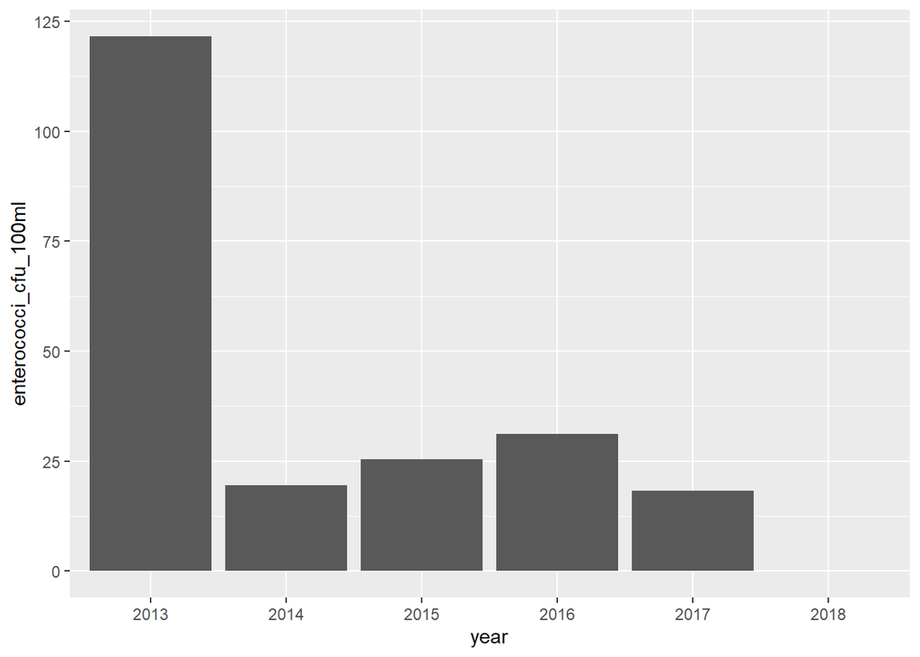

```r
annul_pollution_wide %>%
  filter(site == "Little Bay Beach")%>%
  pivot_longer(-site,
               names_to = "year",
              values_to = "enterococci_cfu_100ml") %>%
  ggplot(aes(x=year,y=enterococci_cfu_100ml))+geom_col()
```

## Knit and Upload

Please knit your work as an .html file and upload to Canvas. Homework is due before the start of the next lab. No late work is accepted. Make sure to use the formatting conventions of RMarkdown to make your report neat and clean!